# 第5回 利子と価格②：物価指数

## 総合の付け替えの式

1. **式**：G31 に `=B31/B$31*100`  
   `B$31` で 2020年の行に留める
2. **下へ**：G31 を G36 まで  
   下へフィル（G31 は 100.0）

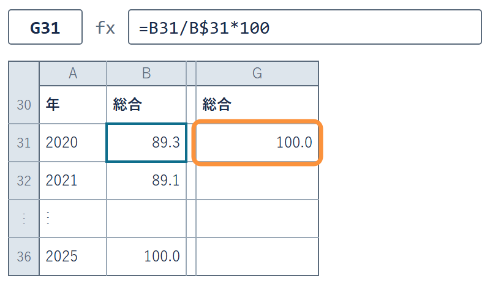

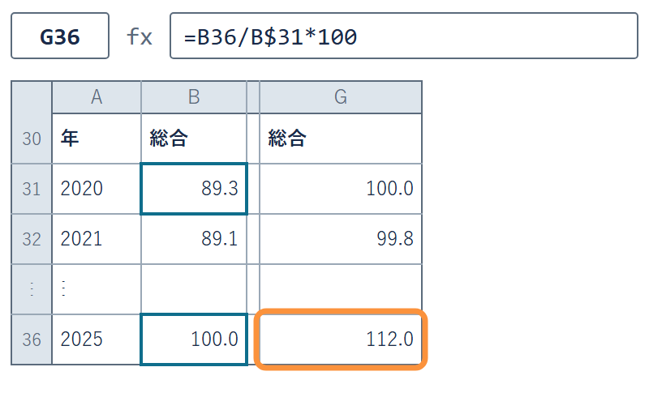

行だけ留める `B$31` は、かごの `B$9` と同じ形

✋ 動画を止めて STEP 1・2 を進め、G36 が 112.0 なら再生に戻る

## 演習 5-2 割る年の付け替え

演習 5-2

割る行を 2022年にすると、2025年と 2020年の総合はいくつか

1. **変える**：G31 の `B$31` を `B$33`（33 行目＝2022年）にして、G36 まで下へ引き直す
2. **書く**：G36 を N4 に、G31 を N5 に、値で打つ
3. **戻す**：G31 を `B$31` に戻して G36 まで引き直し、G36 が 112.0 に戻るのを見る

たしかめ：2025年が 112.0 より、2020年が 100 より小さくなるのはなぜか

✋ 動画を止めて 3 分。N4・N5 に打ち、G31 を戻したら再生に戻る

## 演習 5-2 の答えの例

| セル | 2020年＝100（元） | 2022年＝100 |
| --- | --- | --- |
| G36（2025年） | 112.0 | **109.4** |
| G31（2020年） | 100.0 | **97.7** |

- **N4・N5**：109.4 と 97.7 を打ち、G31 を `B$31` に戻す
- **なぜ小さいか**：2022年は、もう値段が上がっていた。そこを 100 にした

## まとめ

- **複合参照**：動いてほしくない側に `$`。  
  `B$9` は行だけ、`$E13` は列だけ留める
- **今回は**：式 1 本を右と下へ引いて 12 個。`F4` で `$` を切り替える
- **付け替え**：割る相手を変えると 113.1 が 106.3 になる。値段はそのまま
- **CPI**：5 年ごとに基準年改定。  
  2020年＝100 にすると、2025年の総合は 112.0

次は、この指数で金額を測り直す

経済データ入門

第5回 — Topic04

名目値と実質値

初任給は 2 倍になったのか

## この回の道のりと「物価」シート

1

物価指数

2

買い物かご

演習 5-1

野菜の数量

3

複合参照

演習 5-2

割る年の付け替え

4

名目と実質

演習 5-3

女の実質

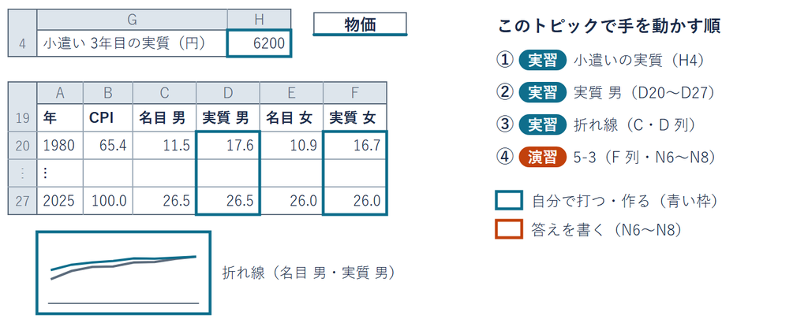

前のトピックの F16（113.1）で、金額を測り直す

## たしかめ 小遣いの増え方と豊かさ

小遣いが 6,200 円から 7,012 円へ（13.1% 増）  
物価指数は 113.1 になった。買える量は、どうなったか

A

**13.1% 豊かになった**

B

**豊かさは変わらない**

**サンプルデータ**：小遣い＝かごの金額  
（lec5-exercise.xlsx「物価」の E13:F16）

1 つ決めてから先へ。答えは次のページで出す

## 小遣いの名目と実質

[figure not shown]

- **サンプルデータ**：lec5-exercise.xlsx「物価」の E13:F16

3年目の値段で 7,012 円は、基準年の値段なら 6,200 円。  
買える量は同じ。答えは B

## 名目値と実質値

用語

**名目値**：書いてある金額のまま（給与明細・値札の数）

**実質値**：基準年の値段で測り直した金額

**実質化**：名目値を物価指数で割り戻し、実質値にすること

式

実質値 ＝ 名目値 ÷ 物価指数 × 100

- **今回は**：7,012 ÷ 113.1 × 100 ≈ 6,200（円）
- **× 100 のわけ**：113.1 は「基準年の 1.131 倍」の意味  
  ÷ 113.1 × 100 は、÷ 1.131 と同じ

## 失敗例 × 100 を忘れる誤り

× 100 を忘れる  
`=E16/F16`  
答えは 62（円）  
100 分の 1 の桁違い

× 100 まで書く  
`=E16/F16*100`  
答えは 6200（円）  
基準年のかごと同じ

- **なぜ起きるか**：物価指数は、基準年を 1 ではなく 100 で表している
- **確かめ方**：答えの桁を、元の金額 7,012 と比べる

## 小遣いの実質の式

1. **選ぶ**：G4 の「小遣い 3年目の  
   実質（円）」の右の H4
2. **式**：H4 に `=E16/F16*100`  
   E16 は 7012・F16 は 113.1

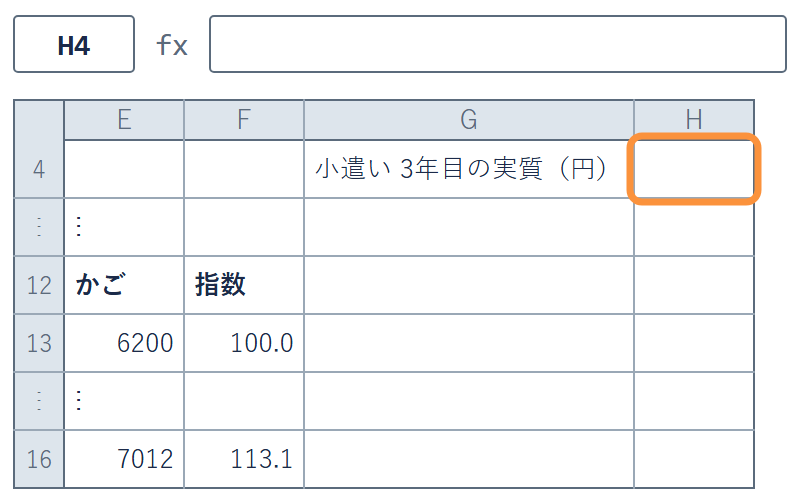

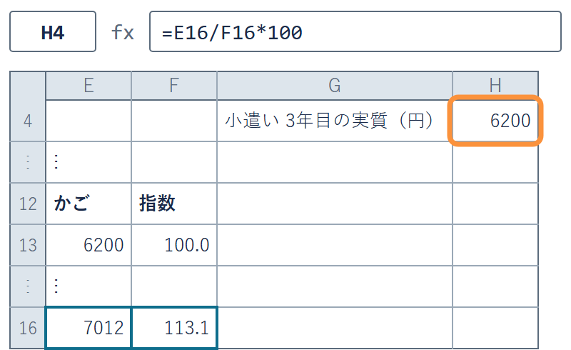

F16 を指すので、6200 ちょうどになる

✋ 動画を止めて STEP 1・2 を進め、H4 が 6200 なら再生に戻る

## 初任給と物価指数の表

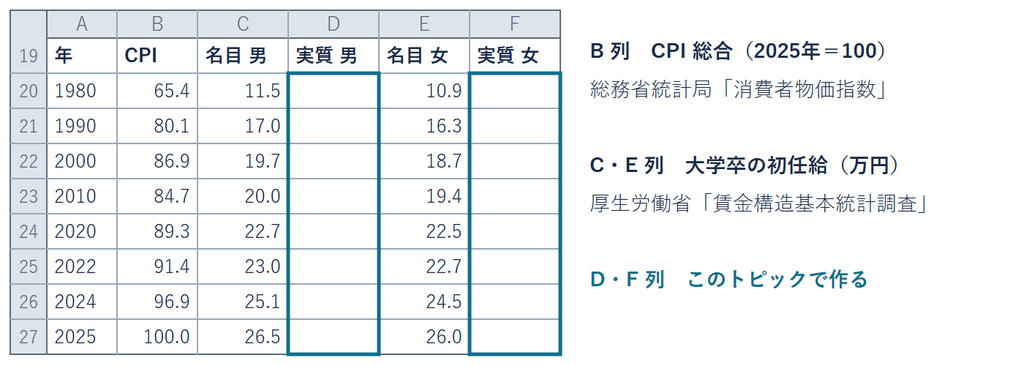

- **出典**：厚生労働省「賃金構造基本統計調査」・総務省統計局  
  「消費者物価指数」・2026-09-22 取得
- **置き場**：lec5-exercise.xlsx「物価」の 19〜27 行（数は印刷済み）

## 初任給の名目と実質

[figure not shown]

- **出典**：厚生労働省（初任給）・総務省統計局（CPI）

1980年の 11.5 万円は、2025年の値段なら 17.6 万円。  
2025年は CPI が 100.0。÷ 100 × 100 で、名目のまま

## 実質の初任給の式

1. **式**：D20 に `=C20/B20*100`  
   名目 ÷ その年の CPI × 100
2. **下へ**：D20 を D27 まで  
   下へフィル
3. **見る**：D27 が 26.5  
   （2025年は名目と同じ）

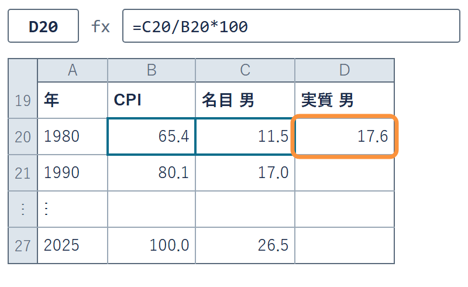

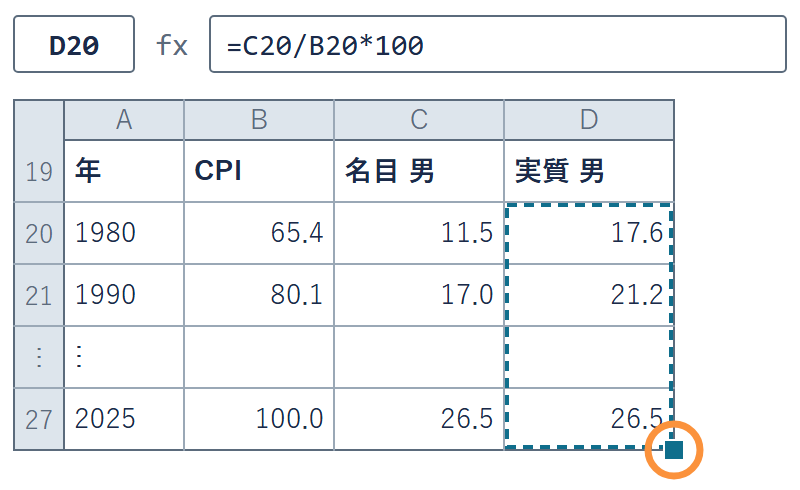

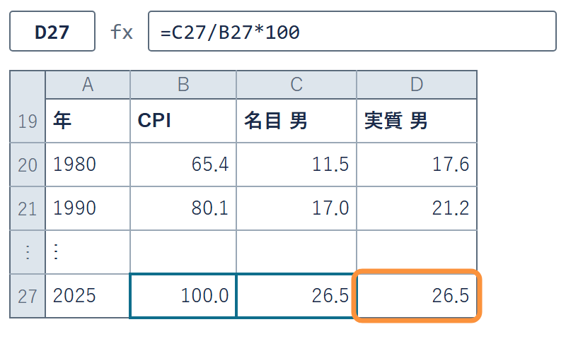

D20 は 17.6 になる。どの行も、その年の CPI で割る

✋ 動画を止めて STEP 1〜3 を進め、D27 が 26.5 なら再生に戻る

## 失敗例 留めすぎた参照の誤り

CPI を `$` で留める  
`=C20/$B$20*100`  
D27 が 40.5  
どの年も 1980年の CPI で割る

`$` を付けない  
`=C20/B20*100`  
D27 が 26.5  
その年の CPI で割る

- **なぜ起きるか**：前のトピックで覚えた `$` を、つい付けたくなる
- **決め**：動いてほしくない側に `$`。ここは CPI も年と一緒に動いてほしい

## 名目と実質の折れ線の作り方

1. **選ぶ**：見出しごと  
   C19:D27 をドラッグ
2. **挿入**：「挿入」→ 折れ線  
   → 折れ線
3. **横軸**：「データの選択」で  
   横軸ラベルを A20:A27 に
4. **見る**：縦軸が 0 から  
   始まっているか

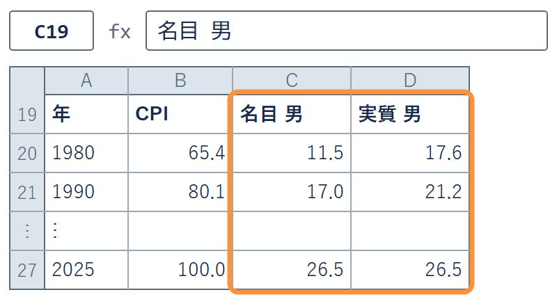

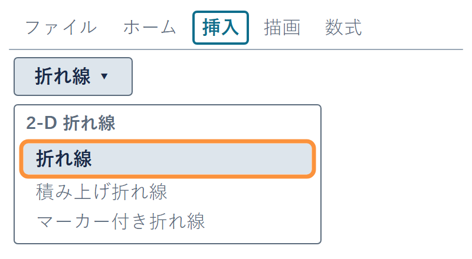

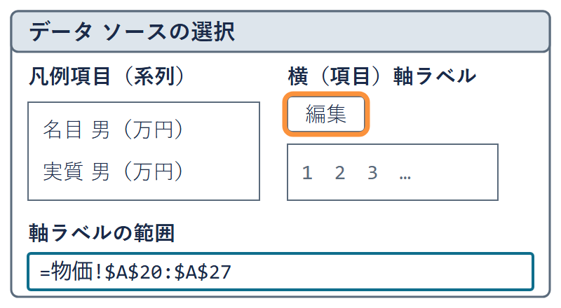

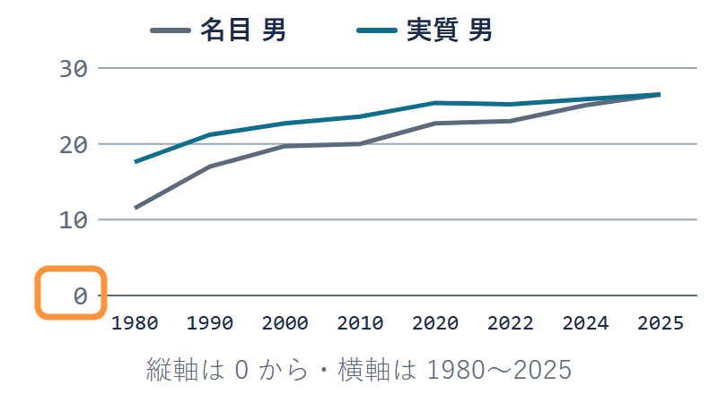

Mac は「グラフのデザイン」→「データの選択」

✋ 動画を止めて STEP 1〜4 を進め、横軸が 1980〜2025 なら再生に戻る

## 名目と実質の折れ線

[figure not shown]

- **横軸**：年の間隔はそろっていない（Excel の折れ線と同じ形）

名目の線の上に、実質の線が重なる。  
昔ほど差が大きく、2025年で同じ 26.5 になる

## 初任給の名目と実質の倍率

[figure not shown]

- **答え**：最初のたしかめは B。2 倍以上とは言えない
- **倍率は目安**：2020年から通勤手当を含む額（厚生労働省）

賃上げのニュースも、名目か実質かを確かめて読む

## 演習 5-3 女の実質

演習 5-3

女の実質を作り、2020年から 2022年の増減を答える

1. **作る**：F20 に、女の名目 E20 を CPI で割り戻す式を入れ、F27 まで下へ
2. **書く**：F24（2020年）を N6 に、F25（2022年）を N7 に、値で打つ
3. **答える**：N8 に「増えた」か「減った」か。名目の E24・E25 とも比べる

✋ 動画を止めて 3 分。N6・N7・N8 に打ったら再生に戻る

## 演習 5-3 の答えの例

| 年 | CPI | 名目 女（万円） | 実質 女（万円） |
| --- | --- | --- | --- |
| 2020（24 行目） | 89.3 | 22.5 | **25.2** |
| 2022（25 行目） | 91.4 | 22.7 | **24.8** |

- **N6・N7・N8**：25.2・24.8・減った。F20 の式は `=E20/B20*100`
- **なぜ減ったか**：名目は 22.5 → 22.7 と増えたが、物価が 2.4% 上がった
- **1980年 → 2025年**：女も名目 約 2.4 倍・実質 約 1.6 倍  
  （目安：1980年の女は事務系だけの値）

## まとめ

- **物価指数**：基準年を 100 として値段を測る。CPI は 2025年＝100
- **買い物かご**：数量を基準年で固定し、全体の動きを 1 つの数にまとめる
- **複合参照**：動いてほしくない側に `$`。`B$9` は行だけ、`$E13` は列だけ
- **基準年**：どの年を 100 にしたかで、指数の数字は変わる
- **名目と実質**：名目値を物価指数で割り戻すと実質値。  
  初任給の実質は約 1.5 倍

お金の数は、どの年の値段で測るかで変わる